# Analysing COVID-19 (2019-nCoV) outbreak data with R - part 2

## By city/province

### Tehran

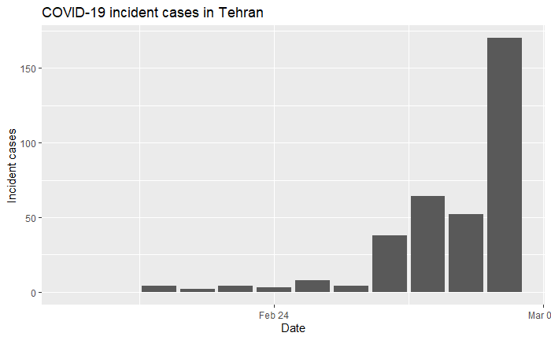

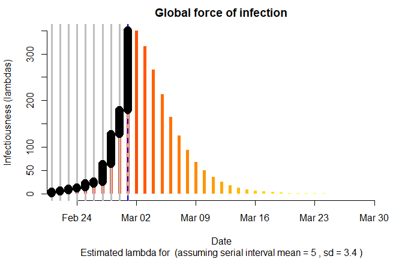

```
Default config will estimate R on weekly sliding windows.
    To change this change the t_start and t_end arguments.
```

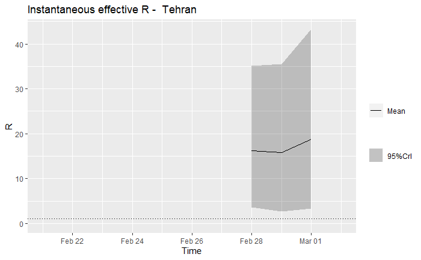

**Assessment**: The outbreak is not under control.

### Qom

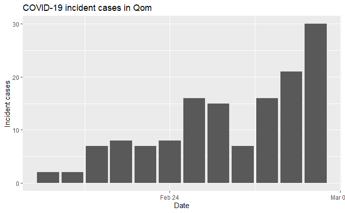

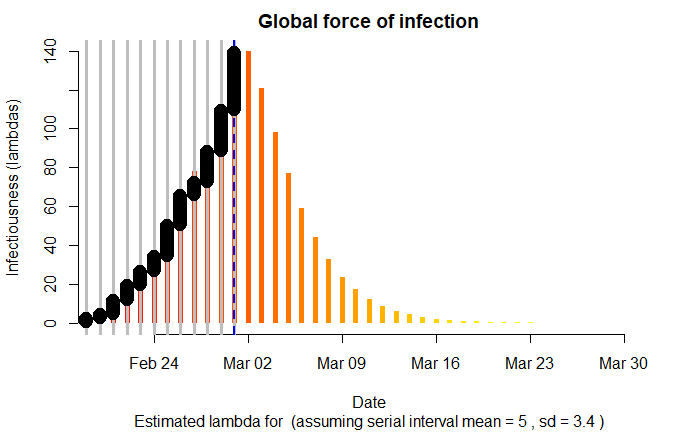

```
Default config will estimate R on weekly sliding windows.
    To change this change the t_start and t_end arguments.
```

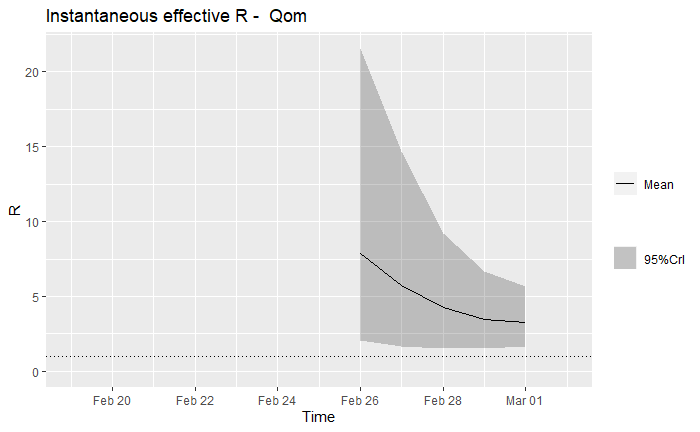

**Assessment**: The outbreak is not yet under control, but the $R_{e}$ is at least falling.

### Gilan

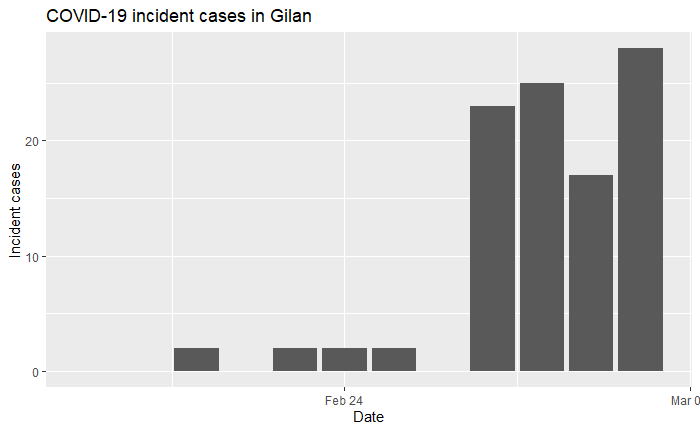

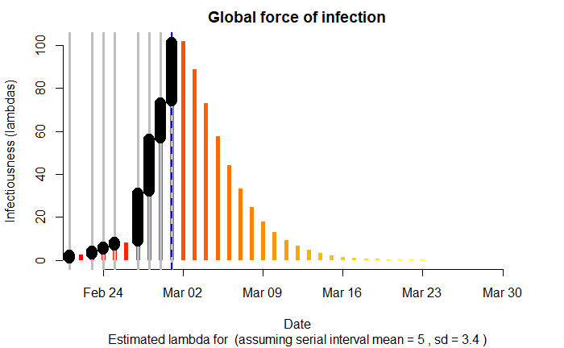

```
Default config will estimate R on weekly sliding windows.
    To change this change the t_start and t_end arguments.
```

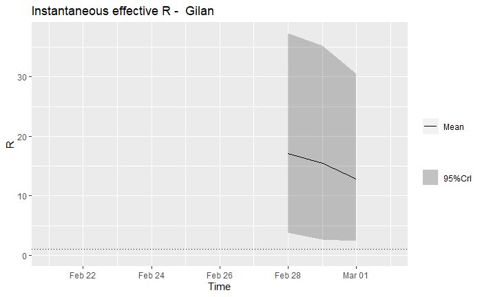

**Assessment**: The outbreak is not yet under control, but the $R_{e}$ may be beginning to fall.

### Summary

Under-ascertainment and/or under-reporting of cases is likely to be a problem in Iran. But even based on the reported incidence figure, local spread has not been contained sufficiently in most of the worst effected Iranian provinces. At the time of writing, we are now seeing asymptomatic or incubation-period travellers from Iran seeding cases around the world.

# Conclusion

The simple visualisations and more sophisticated analyses in this post illustrate how the tools and capabilities of base `R`, the `tidyverse` and the excellent **RECON** packages can be used to assess the progress of the COVID-19 pandemic at national, regional or provincial levels, in a way that is more informative than the cumulative incidence plots which are now everywhere. Data scientists can and should start building such capabilities, right now, to assist international, national and local efforts to contain and slow the spread of the COVID-19 virus. Slowing the spread will save lives by reducing the load on health care facilities, which will be rapidly overwhelmed if transmission of the virus is allowed to proceed unchecked.

[^1]: The same question will need to be answered in many other regions in many other countries before this is all over.
[^2]: Yes, I know the official name for the virus is *SARS-CoV-2*, and that *COVID-19* is the name for the disease it causes. But any mention of *SARS-Cov-2* tends to confuse all but the most expert of audiences.